# Binomial and Geometric Distributions

Applied Statistics

MTH-361A | Spring 2025 | University of Portland

February 17, 2025

# Objectives

- **Develop and understanding of the binomial and geometric distributions**
- **Know how to compute binomial and geometric probabilities using R**
- **Introduce how to simulate binomial and geometric random sampling in R**
- **Activity: Comparing Binomial Distribution with Different Parameters**

# Previously… (1/2)

**The Law of Large Numbers**

It states that as the number of trials in a random experiment increases, the sample mean approaches the expected value.

**Example Bernoulli Trials Simulation**

Let $p=0.60$ be the “success” probability of a Bernoulli r.v. $X$, where $\text{E}(X) = p$.

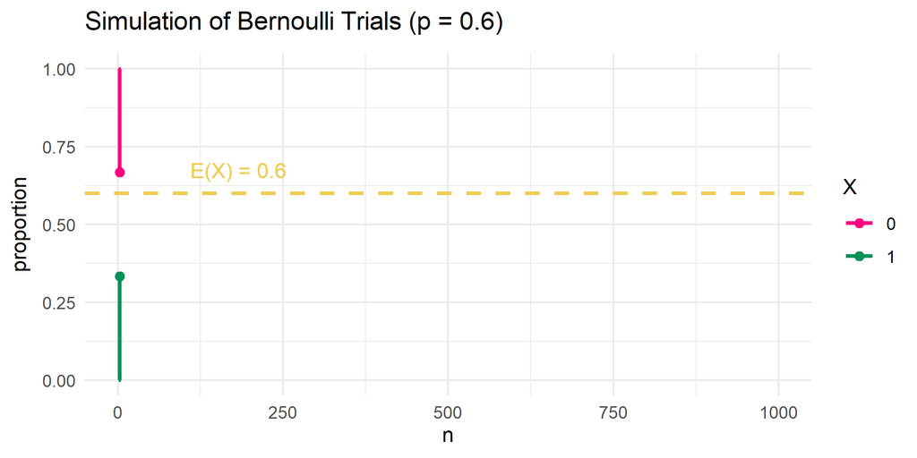

# Previously… (2/2)

**Geometric R.V.**

$$\begin{aligned}
\text{R.V. } & \longrightarrow X \sim \text{Geom}(p) \\
\text{PMF } & \longrightarrow P(X=k) = (1-p)^k p \\
\text{for } & k = 0,1,2, \cdots
\end{aligned}$$

**Binomial R.V.**

$$\begin{aligned}
\text{R.V. } & \longrightarrow X \sim \text{Binom}(p) \\
\text{PMF } & \longrightarrow P(X=k) = \binom{n}{k} p^k (1-p)^{n-k}
\\
\text{for } & k = 0,1,2,3, \cdots, n
\end{aligned}$$

# Visualizing the Geometric Distribution

**Geometric Distribution**

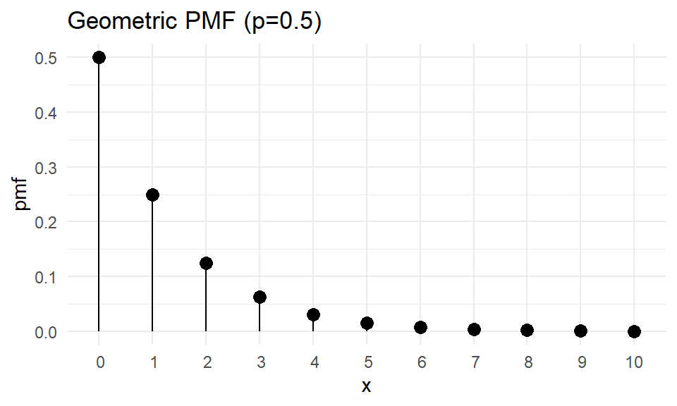

**Geometric R.V.**

Let $p=0.50$ be the success probability.

$$\begin{aligned}
\text{R.V. } & \longrightarrow X \sim \text{Geom}(0.50) \\
\text{PMF } & \longrightarrow P(X=k) = (1-0.50)^k (0.50) \\
\text{for } & k = 0,1,2, \cdots
\end{aligned}$$

# Geometric Probabilities (1/2)

**Geometric Distribution**

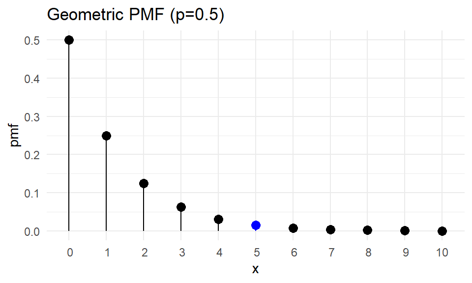

**Example:**

What is the probability of “success” on the 6th trial with $p=0.50$?
$$\begin{aligned}
P(X=5) & = (1-0.50)^5 (0.50) \\
& \approx 0.016
\end{aligned}$$

**Using R:**

```r
p <- 0.5
dgeom(5,p)
```

```
## [1] 0.015625
```

$\star$ Note that the `dgeom()` function computes the probability $P(X = k)$, meaning it computes the probability at exactly $X=k$ using the Geometric PMF.

# Geometric Probabilities (2/2)

**Geometric Distribution**

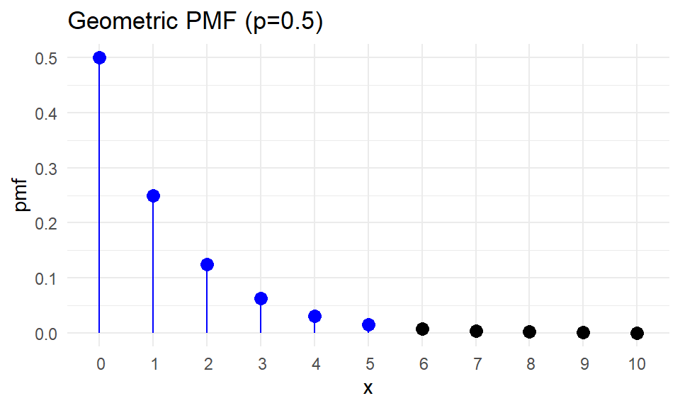

**Example:**

**Using R:**

```r
p <- 0.5
pgeom(5,p)
```

```
## [1] 0.984375
```

$\star$ Note that the `pgeom()` function computes the probability $P(X \le k)$, meaning it computes the sum of all probabilities from $X=0$ to $X=k$ using the Geometric PMF.

# Geometric Expected Value

**Geometric Distribution with Expected Value**

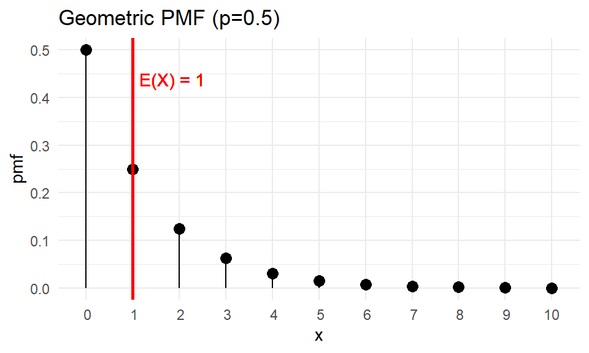

**Geometric R.V.**

Let $p=0.50$ be the success probability.

In general, the expected value of the Geometric r.v. is given by
$$\text{E}(X) = \frac{1-p}{p},$$
which is the ratio of the “fail” and “success” probabilities.

# Simulating the Geometric Distribution

**Random Sampling from the Geometric Distribution**

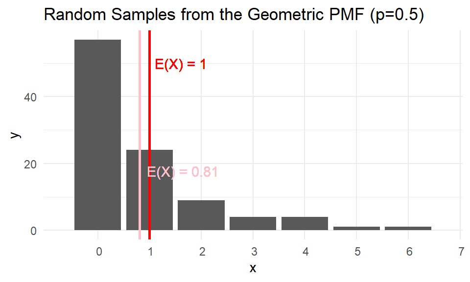

**Sample Mean vs the Expected Value**

**Geometric Random Sampling using R**

```r
N <- 100 # number of simulations
p <- 0.5 # set "success" probability
rgeom(N,p)
```

# Visualizing the Binomial Distribution

**Binomial Distribution**

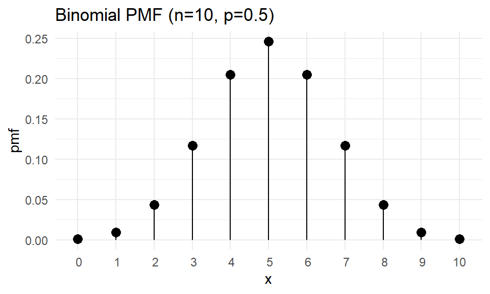

**Binomial R.V.**

Let $p=0.50$ be the “success” probability and $n=10$ the number of trials.

$$\begin{aligned}
\text{R.V. } & \longrightarrow X \sim \text{Binom}(p) \\
\text{PMF } & \longrightarrow P(X=k) = \binom{n}{k} p^k (1-p)^{n-k}
\\
\text{for } & k = 0,1,2,3, \cdots, n
\end{aligned}$$

# Binomial Probabilities (1/2)

**Binomial Distribution**

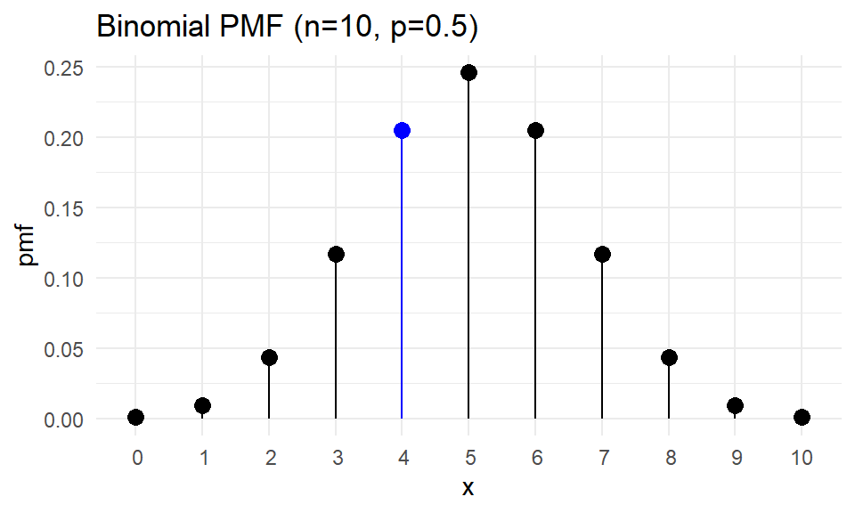

**Example:**

What is the probability of getting 4 “success” in 10 trials with $p=0.50$?
$$\begin{aligned}
P(X=4) & = \binom{10}{4} (0.50)^4 (1-0.50)^{10-4} \\
& = 210 (0.50)^4 (0.50)^{6} \\
P(X=4) & \approx 0.205
\end{aligned}$$

**Using R:**

```r
n <- 10
p <- 0.5
dbinom(4,n,p)
```

```
## [1] 0.2050781
```

$\star$ Note that the `dbinom()` function computes the probability $P(X = k)$, meaning it computes the probability at exactly $X=k$ using the Binomial PMF.

# Binomial Probabilities (2/2)

**Binomial Distribution**

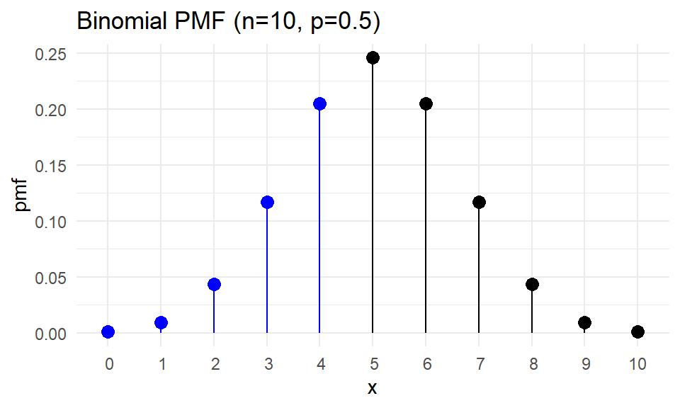

**Example:**

What is the probability of getting at most 4 “success” in 10 trials with $p=0.50$?
$$\begin{aligned}
P(X \le 4) & = \sum_{k=0}^4 P(X = k) \\
& = \sum_{k=0}^4 \binom{10}{k} (0.50)^k (1-0.50)^{10-k}
\\
P(X \le 4) & \approx 0.377 \\
\end{aligned}$$

**Using R:**

```r
n <- 10
p <- 0.5
pbinom(4,n,p)
```

```
## [1] 0.3769531
```

$\star$ Note that the `pbinom()` function computes the probability $P(X \le k)$, meaning it computes the sum of all probabilities from $X=0$ to $X=k$ using the Binomial PMF.

# Binomial Expected Value

**Binomial Distribution with Expected Value**

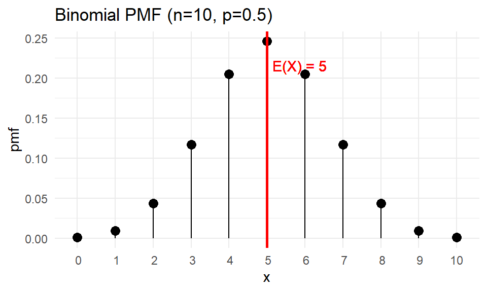

**Binomial R.V.**

Let $p=0.50$ be the success probability and $n=10$ the number of trials.

$$\begin{aligned}
\text{R.V. } & \longrightarrow X \sim \text{Binom}(p) \\
\text{PMF } & \longrightarrow P(X=k) = \binom{n}{k} p^k (1-p)^{n-k}
\\
\text{for } & k = 0,1,2,3, \cdots, n \\
\text{expected value} & \longrightarrow \text{E}(X) \approx 5
\end{aligned}$$

In general, the expected value of the Binomial r.v. is given by
$$\text{E}(X) = np,$$
which is the number of expected “success” in $n$ trials.

# Simulating the Binomial Distribution

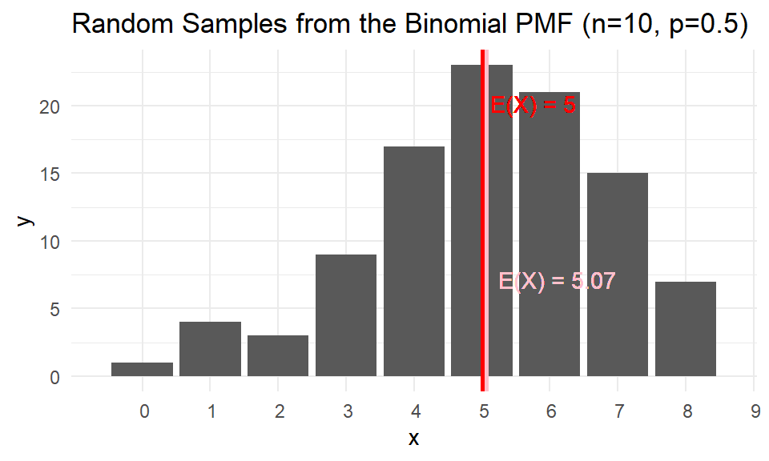

**Sample Mean vs the Expected Value**

```r
N <- 100 # number of simulations
n <- 10 #number of trials
p <- 0.5 # set "success" probability
rbinom(N,n,p)
```

# Geometric vs Binomial Distribution Summary

| **R.V.** $X$ | **Geometric** | **Binomial** |
| --- | --- | --- |
| *Description* | Number of “fail” independent trials before a “success” | Number of “success” in $n$ independent trials |
| *Sampling* | With replacement | With replacement |
| *Parameters* | $p \longrightarrow$ probability of “success” | $n \longrightarrow$ number of trials $p \longrightarrow$ probability of “success” |
| *PMF* | $P(X=k) = (1-p)^k p$ $k=0,1,2,\cdots$ | $P(X=k) = \binom{n}{k} p^k (1-p)^{n-k}$ $k = 0,1,2,3, \cdots, n$ |
| *Expected Value* $\text{E}(X)$ | $\frac{1-p}{p}$ | $np$ |
| $P(X = k)$ | `dgeom(p)` | `dbinom(n,p)` |
| $P(X \le k)$ | `pgeom(p)` | `pbinom(n,p)` |
| $N$ *Simulations* | `rgeom(N,p)` | `rbinom(N,n,p)` |

$\star$ **Key Idea** The basis for both Geometric and Binomial r.v. is the Bernoulli trials but with different counting methodology of “successes”.

# Activity: Comparing Binomial Distribution with Different Parameters

1. Log-in to Posit Cloud and open the R Studio assignment *M 2/17 - Comparing Binomial Distribution with Different Parameters*.
2. Make sure you are in the current working directory. Rename the `.Rmd` file by replacing `[name]` with your name using the format `[First name][Last initial]`. Then, open the `.Rmd` file.
3. Change the author in the YAML header.
4. Read the provided instructions.
5. Answer all exercise problems on the designated sections.

# References

Diez, D. M., Barr, C. D., & Çetinkaya-Rundel, M. (2012). *OpenIntro statistics* (4th ed.). OpenIntro. https://www.openintro.org/book/os/

Speegle, Darrin and Clair, Bryan. (2021). *Probability, statistics, and data: A fresh approach using r*. Chapman; Hall/CRC. https://probstatsdata.com/